# Building Search Engines with Gensim

[figure not shown]

- PhD candidate @ University of Alabama
- Roll tide 🌀🌊🌀🐘🏈💯
- Search applications for software maintenance tasks
  - Code search
  - Change request triage
- Currently visiting researcher @ ABB
  - Looking for new adventures in 2016!
- I have a Twitter ✌️problem✌️
  - I tweet really dumb things sometimes
- I am looking for a job

> I was apparently spotted on the local news being a drunk Alabama fan that flooded the streets after the win last night. Whoops.

> — christop corley (@excsc) [January 10, 2012](https://twitter.com/excsc/status/156821367638077440)

> instead of lunch I am just going to have a bunch of beers and eat pretzels

> — christop corley (@excsc) [September 29, 2014](https://twitter.com/excsc/status/516642590394171393)

*CLARIFICATION: I do not "have a drinking problem", as my mother likes to claim. I am probably actually quite sober right now!

# Let's make a search engine

`search("drunk") => [tweets containing the word 'drunk']`

`search("drunk") => [tweets *related* to the word 'drunk']`

```python
import gensim
```

I'm a `gensim` contributor

`gensim`'s ✌️design✌️ is not always great, certainly better tools exist that can supplement or replace parts of this talk, e.g.:

1. `whoosh`
2. `nltk`
3. `scikit-learn`

### `grep` is great, but

- must search through all documents
- not aware of language-specific semantics
- does not rank by relevence

# Basics

1. **Prepare** the corpus
2. **Model** the corpus
3. **Index** the corpus
4. **Query** fun-time!

```python
cat_phrases = ["meow",
               "meow meow meow hiss",
               "meow hiss hiss",
               "hiss"
              ]
```

```python
cat_lang = ["meow", "hiss"]

cat_phrase_vectors = [[1, 0],
                      [3, 1],
                      [1, 2],
                      [0, 1]]
```

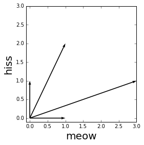

```python
plot_vecs(cat_phrase_vectors, labels=cat_lang)
```

```python
cat_lang = ["meow", "hiss"]

cat_phrase_vectors = [[1, 0],
                      [3, 1],
                      [1, 2],
                      [0, 1]]
other_cat = [1, 1]

plot_vecs(cat_phrase_vectors, other_cat, labels=cat_lang)
```

```python
for cat in cat_phrase_vectors:
    print("%s =>  %.3f" % (cat, 1 - scipy.spatial.distance.cosine(cat, other_cat)))
```

```
[1, 0] =>  0.707
[3, 1] =>  0.894
[1, 2] =>  0.949
[0, 1] =>  0.707
```

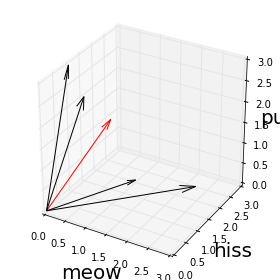

```python
cat_lang3 = ["meow", "hiss", "purr"]

cat_phrase_vectors3 = [[1, 0, 3],
                       [3, 1, 1],
                       [1, 2, 0],
                       [0, 1, 3]]

other_cat3 = [1, 1, 2]

plot_vecs(cat_phrase_vectors3, other_cat3, labels=cat_lang3)  # matplotlib whyyy
```

# Preparing the corpus

1. Tokenizing

```python
text = "Jupyter/IPython notebook export to a reveal.js slideshow is pretty cool!"
text.split()
```

```
['Jupyter/IPython',
 'notebook',
 'export',
 'to',
 'a',
 'reveal.js',
 'slideshow',
 'is',
 'pretty',
 'cool!']
```

```python
list(gensim.utils.tokenize(text))
```

```
[u'Jupyter',
 u'IPython',
 u'notebook',
 u'export',
 u'to',
 u'a',
 u'reveal',
 u'js',
 u'slideshow',
 u'is',
 u'pretty',
 u'cool']
```

## When do we want to tokenize?

```python
list(gensim.utils.tokenize("Jupyter/IPython"))
```

```
[u'Jupyter', u'IPython']
```

```python
list(gensim.utils.tokenize("AC/DC"))
```

```
[u'AC', u'DC']
```

# Preparing the corpus

1. Tokenizing
2. Normalizing

```python
text.lower()
```

```
'jupyter/ipython notebook export to a reveal.js slideshow is pretty cool!'
```

- `"ipython" => "ipython"`
- `"IPython" => "ipython"`
- `"iPython" => "ipython"`

# When do we want to normalize?

```python
"TriPython".lower()
```

```
'tripython'
```

```python
"Apple".lower()
```

```
'apple'
```

# Preparing the corpus

1. Tokenizing
2. Normalizing
3. Stopword removal

```python
' '.join(sorted(gensim.parsing.STOPWORDS))
```

```
'a about above across after afterwards again against all almost alone along already also although always am among amongst amoungst amount an and another any anyhow anyone anything anyway anywhere are around as at back be became because become becomes becoming been before beforehand behind being belo…
```

```python
list(gensim.utils.tokenize(text.lower()))
```

```
[u'jupyter',
 u'ipython',
 u'notebook',
 u'export',
 u'to',
 u'a',
 u'reveal',
 u'js',
 u'slideshow',
 u'is',
 u'pretty',
 u'cool']
```

```python
[word for word in gensim.utils.tokenize(text.lower()) if word not in gensim.parsing.STOPWORDS]
```

```
[u'jupyter',
 u'ipython',
 u'notebook',
 u'export',
 u'reveal',
 u'js',
 u'slideshow',
 u'pretty',
 u'cool']
```

```python
import nltk
nltk.download('stopwords')
' '.join(sorted(nltk.corpus.stopwords.words('english')))
```

```
u'a about above after again against all am an and any are as at be because been before being below between both but by can did do does doing don down during each few for from further had has have having he her here hers herself him himself his how i if in into is it its itself just me more most my m…
```

# When do we want to remove stop words?

```python
[word for word in "the cat sat on the keyboard".split() if word not in gensim.parsing.STOPWORDS]
```

```
['cat', 'sat', 'keyboard']
```

```python
[word for word in "the beatles were overrated".split() if word not in gensim.parsing.STOPWORDS]
```

```
['beatles', 'overrated']
```

# Preparing the corpus

1. Tokenizing
2. Normalizing
3. Stopword removal
   - Short/Long word removal
   - Words that appear in too many or few documents

```python
[word for word in "the cat sat on the keyboard lllllbbbnnnnnbbbbbbbbbbbbbbbbb".split()
      if len(word) > 2 and len(word) < 30]
```

```
['the', 'cat', 'sat', 'the', 'keyboard']
```

# Preparing the corpus

1. Tokenizing
2. Normalizing
3. Stopword removal
4. Stemming

```python
for word in "the runner ran on the running trail for their runs".split():

    stemmed_word = gensim.parsing.stem(word)

    if stemmed_word != word:
        print(word, "=>", stemmed_word)
```

```
running => run
runs => run
```

## When do we want to stem words?

```python
gensim.parsing.stem("running")
```

```
u'run'
```

```python
gensim.parsing.stem("jupyter")
```

```
u'jupyt'
```

### Stemming alternative: lemmatization!

```python
gensim.utils.lemmatize("the runner ran on the running trail for their runs",
                       allowed_tags=re.compile(".*"))
```

```
['the/DT',
 'runner/NN',
 'run/VB',
 'on/IN',
 'the/DT',
 'run/VB',
 'trail/NN',
 'for/IN',
 'their/PR',
 'run/NN']
```

```python
gensim.utils.lemmatize("the runner ran on the running trail for their runs")
```

```
['runner/NN', 'run/VB', 'run/VB', 'trail/NN', 'run/NN']
```

## Putting it all together

```python
def preprocess(text):
    for word in gensim.utils.tokenize(text.lower()):
        if word not in gensim.parsing.STOPWORDS and len(word) > 1:
            yield word

list(preprocess("Jupyter/IPython notebook export to a reveal.js slideshow is pretty cool!"))
```

```
[u'jupyter',
 u'ipython',
 u'notebook',
 u'export',
 u'reveal',
 u'js',
 u'slideshow',
 u'pretty',
 u'cool']
```

```python
gensim.parsing.preprocess_string("Jupyter/IPython notebook export to a reveal.js slideshow is pretty cool!")
```

```
[u'jupyt',
 u'ipython',
 u'notebook',
 u'export',
 u'reveal',
 u'slideshow',
 u'pretti',
 u'cool']
```

# The corpus

My twitter archive

```python
!head -1 tweets.csv
```

```
"tweet_id","in_reply_to_status_id","in_reply_to_user_id","timestamp","source","text","retweeted_status_id","retweeted_status_user_id","retweeted_status_timestamp","expanded_urls"
```

```python
import csv

class TwitterArchiveCorpus():
    def __init__(self, archive_path):
        self.path = archive_path

    def iter_texts(self):
        with open(self.path) as f:
            for row in csv.DictReader(f):
                if (row["retweeted_status_id"] == "" and   # filter retweets
                    not row["text"].startswith("RT @") and
                    row["in_reply_to_status_id"] == "" and # filter replies
                    not row["text"].startswith("@")):

                    yield preprocess(row["text"])

tweets = TwitterArchiveCorpus("tweets.csv")
```

```python
texts = tweets.iter_texts()

print(list(next(texts)))
print(list(next(texts)))
```

```
[u'roll', u'tide', u'roll']
[u'yes', u'yes', u'yes']
```

```python
!head -3 tweets.csv | awk -F '","' '{print $6}'
```

```
text
roll tide roll, y'all.
yes yes yes
```

# Basics

1. **Prepare** the corpus
2. **Model** the corpus
3. **Index** the corpus
4. **Query** fun-time!

```python
plot_vecs(cat_phrase_vectors, other_cat, labels=cat_lang)
```

```python
class TwitterArchiveCorpus():
    def __init__(self, archive_path):
        self.path = archive_path
        self.dictionary = gensim.corpora.Dictionary(self.iter_texts())

    def iter_texts(self):
        with open(self.path) as f:
            for row in csv.DictReader(f):
                if (row["retweeted_status_id"] == "" and    # filter retweets
                    not row["text"].startswith("RT @") and
                    row["in_reply_to_status_id"] == "" and  # filter replies
                    not row["text"].startswith("@")):

                    yield preprocess(row["text"])

    def __iter__(self):
        for document in self.iter_texts():
            yield self.dictionary.doc2bow(document)

    def __len__(self):
        return self.dictionary.num_docs

    def get_original(self, key):
        pass  # let's not look at this :-)

tweets = TwitterArchiveCorpus("tweets.csv")
```

```python
{"meow": 0,
 "hiss": 1,
 "purr": 2}
```

```
{'hiss': 1, 'meow': 0, 'purr': 2}
```

```python
vecs = iter(tweets)

print(next(vecs))
print(next(vecs))
```

```
[(0, 1), (1, 2)]
[(2, 3)]
```

```python
texts = tweets.iter_texts()

print(list(next(texts)))
print(list(next(texts)))
```

```
[u'roll', u'tide', u'roll']
[u'yes', u'yes', u'yes']
```

```python
print(tweets.get_original(0))
print(tweets.get_original(1))
```

```
roll tide roll, y'all.
yes yes yes
```

```python
len(tweets), len(tweets.dictionary)
```

```
(4411, 9294)
```

```python
(len(tweets) * len(tweets.dictionary)) / (1024 ** 2)
```

```
39.0966739654541
```

# Basics

1. **Prepare** the corpus
2. **Model** the corpus
3. **Index** the corpus
4. **Query** fun-time!

```python
plot_vecs(cat_phrase_vectors, other_cat, labels=cat_lang)
```

```python
index = gensim.similarities.Similarity('/tmp/tweets',
                                       tweets,
                                       num_features=len(tweets.dictionary),
                                       num_best=15)
```

```python
!ls /tmp/tweets*
```

```
/tmp/tweets.0
```

# Basics

1. **Prepare** the corpus
2. **Model** the corpus
3. **Index** the corpus
4. **Query** fun-time!

```python
plot_vecs(cat_phrase_vectors, other_cat, labels=cat_lang)
```

```python
query_bow = tweets.dictionary.doc2bow(preprocess("drunk"))
query_bow
```

```
[(1193, 1)]
```

```python
index[query_bow]
```

```
[(275, 0.57735025882720947),
 (2463, 0.57735025882720947),
 (420, 0.44721359014511108),
 (3170, 0.44721359014511108),
 (2530, 0.3333333432674408),
 (3903, 0.31622776389122009),
 (3290, 0.30151134729385376),
 (3928, 0.28867512941360474)]
```

```python
def search(query):

    query_bow = tweets.dictionary.doc2bow(preprocess(query))

    for doc, percent in index[query_bow]:
        print("%.3f" % percent, "=>", tweets.get_original(doc), "\n")
```

```python
search("drunk")
```

```
0.577 => IEEEtrans.cls is drunk

0.577 => The university's DNS is drunk

0.447 => coffee: it's like getting reverse drunk

0.447 => OH: "Drunk screaming hotdog trivia."

0.333 => Damn phone typoing names. BTW I AM DRUNK AT A BOY BAND CONCERT

0.316 => Greatest party theme of the day: Black out in solidarity with internet freedom. #sopa #drunk

0.302 => The chemistry department that we share a building with has alcohol at events all the time. Why aren't I allowed to get drunk in the lab?

0.289 => I was apparently spotted on the local news being a drunk Alabama fan that flooded the streets after the win last night. Whoops.
```

```python
search("bar")
```

```
0.516 => the sports bar I went to watch the game at doesn't even get SEC network what kind of garbage "sports bar" is this

0.500 => Cashing your check at the bar. #classy

0.378 => guy at bar next to me just told someone  he once worked 175 hours in one week. lol.

0.354 => Summertime translation: candy bar &lt;-&gt; corn ear

0.354 => Current status: Spongebob and Patrick have just entered the Thug Tug bar...

0.354 => *puts pants on, goes to hotel bar to drink away this game*

0.354 => Dude next to me at the airport bar is chewing with his mouth open and I just want to scream.

0.333 => Just saw a bar touchscreen game get rebooted. Apparently this one runs Linux. TIL.

0.333 => im trying to have a proper gameday in Canada and nobody in this bar knows how to make bloody marys.

0.302 => Looks like my laundromat/bar crossover idea has already been implemented: http://t.co/x35btduo /cc @o_kimly

0.289 => Trying to convince myself to go to a health bar and have some health beers so I can watch the hockey game in HD

0.277 => Here's to hoping I have decent cell phone service in the small town of Gordo, AL. Was informed there won't be a bar at this wedding.

0.277 => Robotics Competition volunteer lunch. Yum! (@ Kobe Japanese Steakhouse &amp; Sushi Bar) http://t.co/BttOMWCo

0.258 => Coffee shop meets laundromat. Not as good as my bar laundromat idea, but much better than regular laundromats. Call it Clean Beans.

0.250 => Favorite thing about Firefox is that the address bar doesn't do a search for "nerds.jpg", but assumes ".jpg" is a TLD &amp; attempts connection
```

# A more slightly more advanced model

```python
lsi = gensim.models.LsiModel(tweets,
                             num_topics=100,
                             power_iters=10,
                             id2word=tweets.dictionary)
```

```python
len(tweets), len(tweets.dictionary)
```

```
(4411, 9294)
```

```python
len(tweets), lsi.num_topics
```

```
(4411, 100)
```

```python
lsi_index = gensim.similarities.Similarity('/tmp/lsitweets',
                                           lsi[tweets],
                                           num_features=lsi.num_topics,
                                           num_best=15)
```

```python
def lsi_search(query):

    query_bow = tweets.dictionary.doc2bow(preprocess(query))

    for doc, percent in lsi_index[lsi[query_bow]]:
        print("%.3f" % percent, "=>", tweets.get_original(doc), "\n")
```

```python
search("pigpen") # non-LSI search
```

```
0.378 => my cats names are bubbie and pigpen. why haven't I been signing off emails with 👨👵🐷?

0.378 => pigpen really enjoys rolling around on the ground. http://t.co/1se5FPsXnM
```

```python
lsi_search("pigpen")
```

```
0.975 => my cats names are bubbie and pigpen. why haven't I been signing off emails with 👨👵🐷?

0.937 => i only interact with #brands if they ask me about my cats first

0.933 => my cats are currently flipping out about #meowthejewels

0.923 => the travel tranquilizers I gave my cats made one of them cross-eyed

0.917 => one of my cats definitely chases her tail

0.891 => Snapchat videos of my cats meowing as apologies as a service

0.798 => So I played my unsent Snapchat of my cats being cute as hell during a midterm when I went to view one sent to me

0.785 => It's always so difficult to sleep in unfamiliar places. But at least there are two cats to keep me company on this couch

0.768 => update: cats still playing with bug. it's not as dead as I originally thought

0.746 => Yelling at my cats to go back to bed, it's too early, and take off all that swag you look ridiculous

0.743 => Instead of screaming "rolllllllllllll tide roll" we pounce on the string and go "..." because cats don't yell while killing, dummy

0.712 => I should invest in one of those networked webcams so I can look at my cats while I'm away on trips

0.664 => The cats and I decided we would have our own party. It involves running around the apartment with string, because f the police

0.644 => Spiders will never ever be cute

0.626 => MARITAL STATUS:
☐ Single
☐ Married
☐ Divorced
☑ Single, but happily with cats
```

# WE NEED TO GO DEEPER *BRRRRRRRAAAAAWWWWRWRRRMRMRMMMMM*

[figure not shown]

## A deep-learning approach

Warning: here be Gensim dragons

gif credit: http://prostheticknowledge.tumblr.com/post/128044261341/implementation-of-a-neural-algorithm-of-artistic

```python
w2v = gensim.models.Word2Vec.load_word2vec_format('GoogleNews-vectors-negative300.bin.gz',
                                                  binary=True)
```

### How does "king - man + woman = queen"?

[figure not shown]

gif credit: http://multithreaded.stitchfix.com/blog/2015/03/11/word-is-worth-a-thousand-vectors/

```python
def generate_vector_sums():
    for doc in tweets.iter_texts():  # remember me?
        yield gensim.matutils.unitvec(  # DRAGON: hack to make Similarity happy with fullvecs
            sum(
                (w2v[word] for word in doc if word in w2v),
                numpy.zeros(w2v.vector_size)
            )
        )

w2v_index = gensim.similarities.Similarity('/tmp/w2v_tweets',
                                           generate_vector_sums(),
                                           num_features=w2v.vector_size,
                                           num_best=15)
```

```python
def search_w2v(query):
    query_tokens = preprocess(query)
    query_vec = gensim.matutils.unitvec(sum((w2v[word] for word in query_tokens if word in w2v), numpy.zeros(w2v.vector_size)))

    for doc, percent in w2v_index[query_vec]:
        print("%.3f" % percent, "=>", tweets.get_original(doc), "\n")
```

```python
search_w2v("drunk")
```

```
0.740 => IEEEtrans.cls is drunk

0.606 => The university's DNS is drunk

0.594 => OH: "Drunk screaming hotdog trivia."

0.542 => coffee: it's like getting reverse drunk

0.521 => Damn phone typoing names. BTW I AM DRUNK AT A BOY BAND CONCERT

0.492 => I was apparently spotted on the local news being a drunk Alabama fan that flooded the streets after the win last night. Whoops.

0.481 => i should be reading papers but instead i am drinking coffee and being pumped about drinking more coffee #coffee

0.474 => Vim is old enough to drink, y'all. https://t.co/qfZqzlx7Qm

0.469 => Hey there random anxiety, what an appropriate time to show up. Another beer please, bartender!

0.469 => Just accidentally killed a job that has been running since April.

Welp, time to drink.

0.466 => how many red bulls can one drink before 7am?

a lot

0.463 => Day made by a cyclist cussing out a bro in his truck

0.452 => damn, someone already beat me to that mango drink name http://t.co/hWzbo3j6de

0.437 => This is how gangsters drink coffee while reviewing papers. http://t.co/7e5l5RHr

0.436 => The chemistry department that we share a building with has alcohol at events all the time. Why aren't I allowed to get drunk in the lab?
```

```python
search_w2v("kittens")
```

```
0.577 => Cat cuddles http://t.co/zPNgmwTqz7

0.549 => Just saw a bunny while I was walking the dog! Bunnies :)

0.547 => Snapchat videos of my cats meowing as apologies as a service

0.518 => Picked my kitty up from being spayed today, and Vet tells me she's not allowed to run or jump. Vet has never had a kitten before, apparently

0.518 => lap cat is best cat http://t.co/x7ZYkVqbC2

0.511 => The cat met her after school to walk her home. I wish my cats did that.

0.511 => I don't see giant roaches often, but when I do, it's because the cats are already on the case #leakyboat http://t.co/QvItKpQFz7

0.510 => "You are a kitten in a catnip forest" ok http://t.co/XyFNkoW80b

0.502 => ahh, my kitties! 👨👵🐷💕

0.500 => A large pool filled with kittens is also acceptable

0.494 => my cats are currently flipping out about #meowthejewels

0.489 => actually there are like 5 kittens around that lot 🐱 🐱 🐱 🐱 🐱

0.488 => Cats really like my feet http://t.co/LuAclUIcTb

0.488 => someone come over and throw cat treats across the room. i am stuck under this sleeping cat

0.484 => things i am thankful for: lap cats http://t.co/iwyid8jx8l
```

# Thanks for listening! 😻🍻😸

(Is it beer-time yet?)

```python
plot_vecs(cat_phrase_vectors, other_cat, labels=["meow", "hiss"])
```

No tweets were harmed as a result of this talk.  
I am a person; people make mistakes and that's okay.

### Short-circuiting a full search: inverted index!

```python
cat_lang3 = ["meow", "hiss", "purr"]

cat_phrase_vectors3 = [[1, 0, 3],
                       [3, 1, 1],
                       [1, 2, 0],
                       [0, 1, 3]]

inv_index = defaultdict(set)

for doc_id, doc in enumerate(cat_phrase_vectors3):
    for word_id, freq in enumerate(doc):
        if freq:
            inv_index[word_id].add(doc_id)
```

```python
inv_index[0]
```

```
{0, 1, 2}
```

```python
inv_index[0].intersection(inv_index[1])
```

```
{1, 2}
```

Download this notebook